# Capital Bikeshare System Analysis

```r
test$tst.cnt[test$tst.cnt < 0] = 0
tst.MSE <- sum((test$cnt - test$tst.cnt)^2)/nrow(test)
tst.MSE
```

```
## [1] 921191.7
```

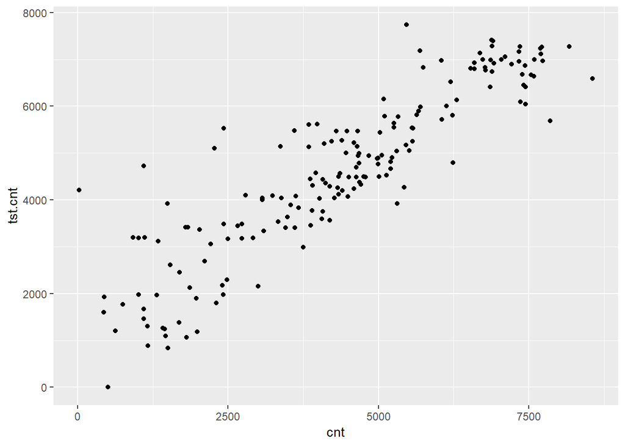

```r
tst.result <- ggplot(test,aes(cnt,tst.cnt))+geom_point()
tst.result
```

```r
#reduce model by what was found insignificant in the last model
fit_3 <- lm(cnt ~ season + yr + weathersit + temp + hum + windspd, train)
summary(fit_3)  #all significant
```

```
##
## Call:
## lm(formula = cnt ~ season + yr + weathersit + temp + hum + windspd,
##     data = train)
##
## Residuals:
##     Min      1Q  Median      3Q     Max
## -3739.7  -404.3    37.9   498.3  3385.1
##
## Coefficients:
##               Estimate Std. Error t value Pr(>|t|)
## (Intercept)   3029.809    307.985   9.838  < 2e-16 ***
## seasonSpring  -327.907    111.165  -2.950 0.003318 **
## seasonSummer  -577.227    140.589  -4.106 4.65e-05 ***
## seasonWinter -1550.581    107.514 -14.422  < 2e-16 ***
## yr            2049.773     69.410  29.532  < 2e-16 ***
## weathersit    -586.867     84.155  -6.974 9.01e-12 ***
## temp            55.775      4.197  13.288  < 2e-16 ***
## hum            -13.094      3.495  -3.746 0.000199 ***
## windspd      -2912.287    484.116  -6.016 3.29e-09 ***
## ---
## Signif. codes:  0 '***' 0.001 '**' 0.01 '*' 0.05 '.' 0.1 ' ' 1
##
## Residual standard error: 802.4 on 543 degrees of freedom
## Multiple R-squared:  0.8242, Adjusted R-squared:  0.8216
## F-statistic: 318.2 on 8 and 543 DF,  p-value: < 2.2e-16
```

```r
tst.cnt <- predict(fit_3, test)
test$tst.cnt <- tst.cnt
tst.MSE <- sum((test$cnt - test$tst.cnt)^2)/nrow(test) ##MSE Formula
tst.MSE
```

```
## [1] 937939.1
```

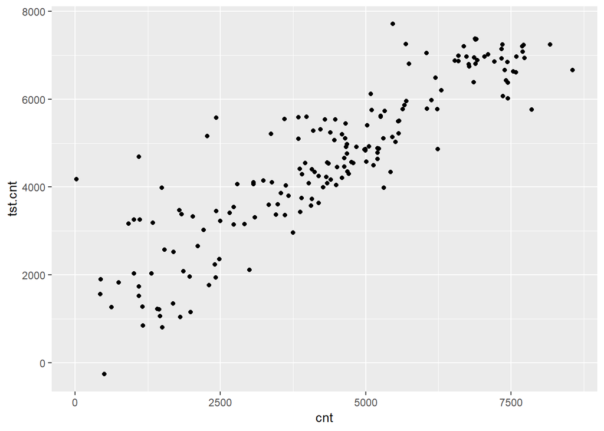

```r
tst.result = ggplot(test,aes(cnt,tst.cnt))+geom_point()
tst.result
```

```r
test$tst.cnt[test$tst.cnt < 0] = 0
tst.MSE <- sum((test$cnt - test$tst.cnt)^2)/nrow(test)
tst.MSE
```

```
## [1] 936103.5
```

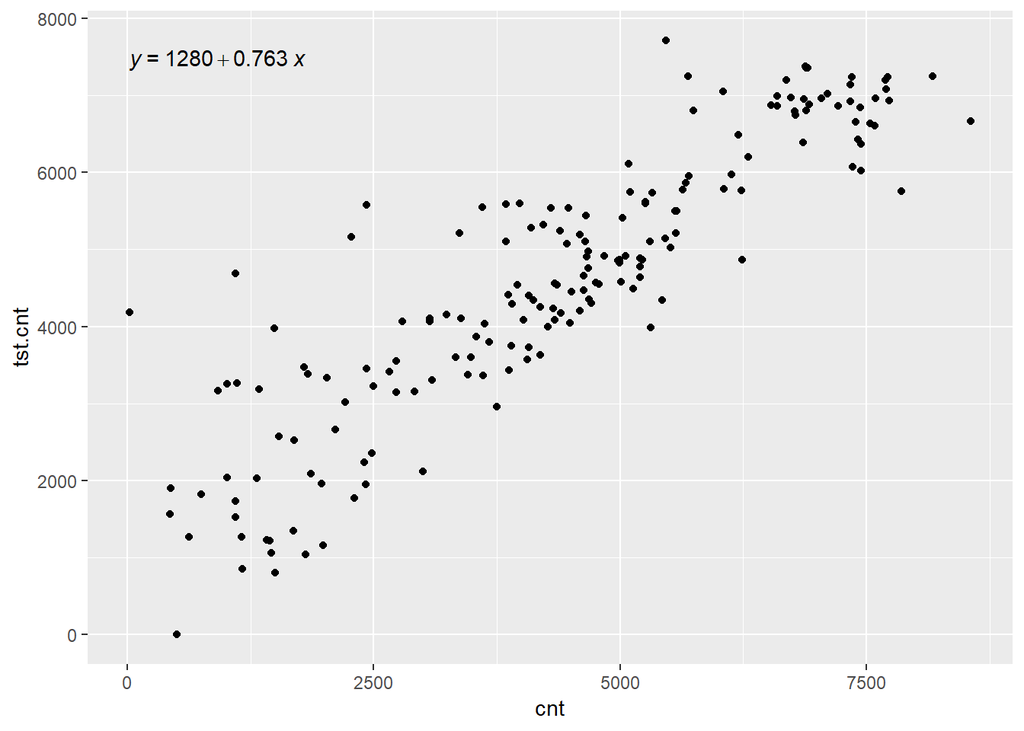

```r
tst.result <- ggplot(test,aes(cnt,tst.cnt))+geom_point()+
  stat_poly_eq(parse =T, aes(label= ..eq.label..), formula = y~x)
tst.result
```

# Deeper Dive

A further look into the data could have shown a more clear predictor of the data. A closer look at the number of riders in relation to the date shows a potential time series. Further analysis into time series packages could reveal more precise values. An off basis analysis found the data to be non-stationary.

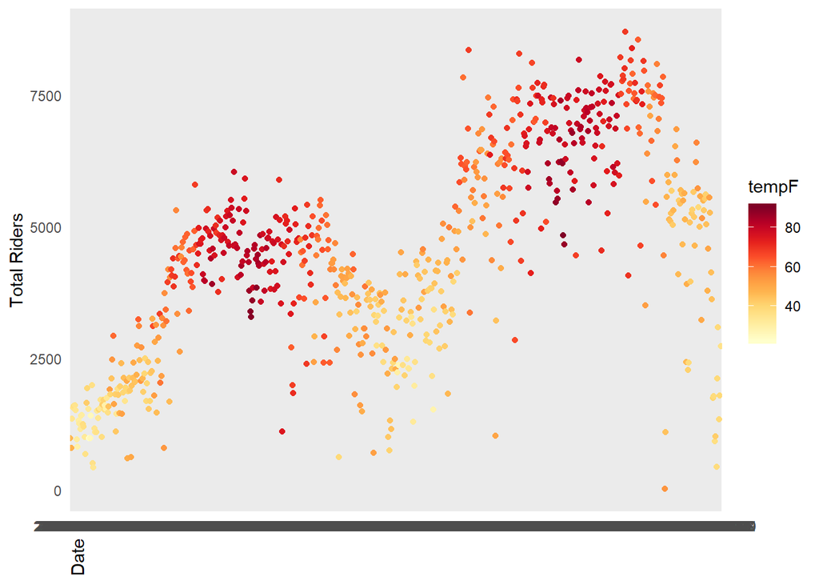

Some additional variables would be good to know for further analysis. For instance, we our number of riders is not defined as unique riders or repeat customers for the day. What proportion of DC’s population is a registered user? How does that proportion change over this 2 year period? How quickly did the market saturate if it did?

A deeper categorization of the weather category could also lead to more conclusive results. For weather to be broken into 4 categories, and a single category only referenced 3-4 times on the hourly dataset means better data collection could have been done in this particular field.

# Conclusion